# R Notebook

# Spectral variance across the western United States

## Setup Python environment

I’m using the environment provided by the Earth Data Science class. https://www.earthdatascience.org/workshops/setup-earth-analytics-python/

I’m running python from Rstudio. This chunk tells rstudio how to find that environment.

```r
library(reticulate)
library(usethis)

#use_python("/Users/ty/opt/miniconda3/bin/python")
#use_virtualenv("~/myenv")
#use_condaenv(condaenv = "r-nlp", conda = "/Users/ty/opt/miniconda3/envs/earth-analytics-python/opt/miniconda3")
#use_virtualenv("/Users/ty/opt/miniconda3/envs/earth-analytics-python/bin/python3")
py_config()
```

```
python:         /Users/ty/opt/miniconda3/envs/earth-analytics-python/bin/python3.8
libpython:      /Users/ty/opt/miniconda3/envs/earth-analytics-python/lib/libpython3.8.dylib
pythonhome:     /Users/ty/opt/miniconda3/envs/earth-analytics-python:/Users/ty/opt/miniconda3/envs/earth-analytics-python
version:        3.8.12 | packaged by conda-forge | (default, Oct 12 2021, 21:50:38)  [Clang 11.1.0 ]
numpy:          /Users/ty/opt/miniconda3/envs/earth-analytics-python/lib/python3.8/site-packages/numpy
numpy_version:  1.22.1

NOTE: Python version was forced by RETICULATE_PYTHON
```

```r
reticulate::repl_python()
```

```
Python 3.8.12 (/Users/ty/opt/miniconda3/envs/earth-analytics-python/bin/python3.8)
Reticulate 1.24 REPL -- A Python interpreter in R.
Enter 'exit' or 'quit' to exit the REPL and return to R.
```

```r
quit
edit_r_environ()
```

```
• Modify '/Users/ty/.Renviron'
• Restart R for changes to take effect
```

Load python packages

```python
reticulate::repl_python()
import pandas as pd
import geopandas
import matplotlib.pyplot as plt
import numpy as np
import plotnine
import contextily as cx
import requests
import json
```

## Filter metadata to decide what you’re going to try to download.

A small csv version of the neon metadate exists on the NEON website. Download this file and load it into python. https://www.neonscience.org/resources/learning-hub/tutorials/neon-api-01-introduction-requests

```python
print(metadata.field_site_id)
```

```
0     ABBY
1     ARIK
2     BARC
3     BARR
4     BART
      ...
76    WALK
77    WLOU
78    WOOD
79    WREF
80    YELL
Name: field_site_id, Length: 81, dtype: object
```

## R code to translate into python code

```r
library(tidyverse)
library(sf)
library(maps)
```

Steps: 1) Read in the metadata csv 2) Spatially project those metadata so we can do spatial filters 3) Calculate a bounding box around the available NEON sites 4) Download a basemap and make sure it has the same spatial projection as your data.

```r
bb
```

```
      xmin       ymin       xmax       ymax
-156.61936   17.96955  -66.79868   71.28241
```

Plot the NEON sites

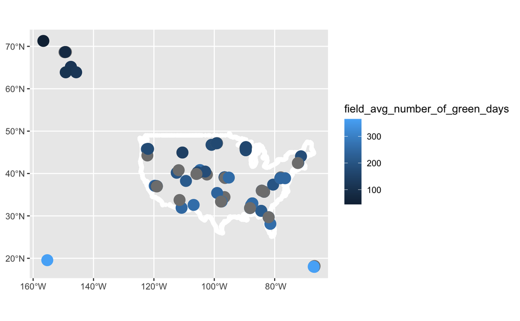

```r
ggplot() +
  geom_sf(data = usa, col="white") +
  geom_sf(data=metatdata,aes( color=field_avg_number_of_green_days), size=5) +
  coord_sf(xlim = c(bb[1], bb[3]), ylim = c(bb[2], bb[4]))
```

Filter your data to only include terrestrial sites

```r
terrestrial_sites <- metatdata %>%
  filter(field_site_type == "Core Terrestrial" | field_site_type == "Gradient Terrestrial" )

as.data.frame(terrestrial_sites)
```

|  | field_domain_id | field_site_id | field_site_name | field_site_type | field_site_subtype | field_colocated_site | field_site_host | field_site_url | field_nonneon_research_allowed | field_access_details | field_neon_field_operations_office | field_geodetic_datum | field_utm_northing | field_utm_easting | field_utm_zone | field_site_county | field_site_state | field_site_country | field_mean_elevation_m | field_minimum_elevation_m | field_maximum_elevation_m | field_mean_annual_temperature_C | field_mean_annual_precipitation_mm | field_dominant_wind_direction | field_mean_canopy_height_m | field_dominant_nlcd_classes | field_domint_plant_species | field_usgs_huc | field_watershed_name | … |
| --- | --- | --- | --- | --- | --- | --- | --- | --- | --- | --- | --- | --- | --- | --- | --- | --- | --- | --- | --- | --- | --- | --- | --- | --- | --- | --- | --- | --- | --- | --- |
| 1 | D16 | ABBY | Abby Road NEON | Gradient Terrestrial |  |  | Washington Department of Natural Resources | https://www.dnr.wa.gov/ | Limited | Reseachers should coordinate with the site manager and submit a site research permit. | Domain 16 Support Facility | WGS84 | 5067870 | 552075.5 | 10N | Clark | WA | USA | 365 | NA | 708 | 10.0 | 2451 |  | 34m (in surrounding non-logged area) | Evergreen Forest\|Grassland/Herbaceous\|Shrub/Scrub | Gaultheria shallon (salal)\|Pseudotsuga menziesii (douglas fir)\|Pteridium aquilinum (bracken fern) |  |  | … |
| 2 | D18 | BARR | Utqiaġvik NEON | Gradient Terrestrial |  |  | Ukpeagvik Inupiat Corporation | http://www.north-slope.org/departments/planning-community-services/applications-and-forms | Yes | Reseachers should coordinate with the site manager and submit appropriate site research-access permit. | Domain 18/19 Support Facility | WGS84 | 7910572 | 585246.1 | 4N | North Slope | AK | USA | 4 | 0 | 13 | -12.0 | 105 | E | 0.3 | Emergent Herbaceous Wetlands | Carex aquatilis (water sedge)\|Dupontia fisheri (Fisher's tundragrass)\|Petasites frigidus (Arctic sweet coltsfoot) |  |  | … |
| 3 | D01 | BART | Bartlett Experimental Forest NEON | Gradient Terrestrial |  |  | Northern Research Station, US Forest Service | https://www.nrs.fs.fed.us/ef/locations/nh/bartlett/ | Yes | Bartlett Experimental Forest has very limited staff and the USFS personnel are NOT available to support external researchers. Permitting requests for research activities should be submitted at least 6… | Domain 01 Support Facility | WGS84 | 4881512 | 316812.2 | 19N | Carroll | NH | USA | 274 | 230 | 655 | 6.2 | 1325 | S | 23 | Deciduous Forest\|Evergreen Forest\|Mixed Forest | Fagus grandifolia (American beech)\|Tsuga canadensis (Eastern hemlock)\|Acer rubrum (Red maple) |  |  | … |
| 4 | D02 | BLAN | Blandy Experimental Farm NEON | Gradient Terrestrial |  | LEWI | University of Virginia\|Private Land | http://blandy.virginia.edu/research\| | Yes (Tower and TIS) / Very Limited | Research activity at the NEON tower area via University of Virginia. / Very limited available via private land owner. | Domain 02 Support Facility | WGS84 | 4327546 | 753379.5 | 17N | Clarke | VA | USA | 183 | 119 | 193 | 12.1 | 983 | NW | 1 | Deciduous Forest\|Pasture/Hay | Rhamnus davurica (dahurian buckthorn)\|Lonicera maackii (amur honeysuckle)\|Juglans nigra (eastern black walnut) |  |  | … |
| 5 | D19 | BONA | Caribou-Poker Creeks Research Watershed NEON | Core Terrestrial |  | CARI | University of Alaska | https://www.uaf.edu/uaf/ | Yes | NEON site is colocated with Boreal LTER. Please allow extra lead time (3-6 months prior to planned start) for coordination requirements; coordinate with site manager | Domain 18/19 Support Facility | WGS84 | 7225713 | 476436.7 | 6N | Fairbanks North Star | AK | USA | 230 | 212 | 728 | -3.0 | 262 | W | 8 | Deciduous Forest\|Evergreen Forest\|Mixed Forest\|Woody Wetlands | Picea mariana (black spruce)\|Populus tremuloides (quaking aspen)\|Alnus viridis (green alder) |  |  | … |
| 6 | D11 | CLBJ | Lyndon B. Johnson National Grassland NEON | Core Terrestrial |  | PRIN | US Forest Service | https://www.fs.usda.gov/detail/texas/about-forest/districts/?cid=fswdev3_008440 | Very Limited | Researchers should coordinate directly with the US Forest Service for permitting and approval. Site host is very limited to external research requests. | Domain 11 Support Facility | WGS84 | 3696682 | 632982.2 | 14N | Wise | TX | USA | 272 | 258 | 343 | 17.5 | 926 | S | 13 | Deciduous Forest\|Grassland/Herbaceous | Quercus stellata (post oak)\|Quercus marilandica (blackjack oak) |  |  | … |
| 7 | D10 | CPER | Central Plains Experimental Range NEON | Core Terrestrial |  |  | USDA-Agricultural Research Service | https://www.ars.usda.gov/plains-area/fort-collins-co/center-for-agricultural-resources-research/rangeland-resources-systems-research/docs/rrsr/central-plains-experimental-research-location/ | Yes | Reseachers should coordinate with the site manager. | Domain 10/13 Support Facility | WGS84 | 4518311 | 521454.8 | 13N | Weld | CO | USA | 1654 | 1601 | 1686 | 8.6 | 344 | NW | 0.4 | Grassland/Herbaceous | Bouteloua gracilis (Blue grama)\|Hesperostipa comata (Needle-and-thread grass)\|Thelesperma filifolium (Stiff greenthread) |  |  | … |
| 8 | D09 | DCFS | Dakota Coteau Field Site NEON | Gradient Terrestrial |  | PRLA | North Dakota Land Trust | https://www.land.nd.gov/ | Yes | Reseachers should coordinate with the site manager. | Domain 09 Support Facility | WGS84 | 5223133 | 491923.5 | 14N | Stutsman | ND | USA | 575 | 494 | 592 | 4.9 | 490 | NW | 0.4 | Grassland/Herbaceous | Elaeagnus commutata (slilverberry)\|Poa pratensis (Kentucky bluegrass)\|Crataegus chrysocarpa (fireberry hawthorn) |  |  | … |
| 9 | D19 | DEJU | Delta Junction NEON | Gradient Terrestrial |  |  | Bureau of Land Management | https://www.blm.gov/office/eastern-interior-field-office | Yes | Reseachers should coordinate with the site manager. | Domain 18/19 Support Facility | WGS84 | 7084367 | 561330.1 | 6N | Southeast Fairbanks | AK | USA | 517 | 444 | 581 | -3.0 | 305 | E | 10 | Evergreen Forest\|Shrub/Scrub\|Woody Wetlands | Picea mariana (black spruce)\|Vaccinium vitis-idaea (lingonberry)\|Betula glandulosa / Betula (American dwarf birch) |  |  | … |
| 10 | D08 | DELA | Dead Lake NEON | Gradient Terrestrial |  | BLWA | US Army Corps of Engineers | https://www.sam.usace.army.mil/ | Limited | This area is primarily intended to provide recreational opportunities and is also classified as a hunting area. As such, access is very limited but potentially possible. | Domain 08 Support Facility | WGS84 | 3524155 | 389259.0 | 16N | Greene | AL | USA | 25 | 21 | 41 | 17.6 | 1372 | SW | 30 | Evergreen Forest\|Woody Wetlands | Quercus nigra (Water oak)\|Celtis laevigata (Sugarberry)\|Acer rubrum (Red maple) |  |  | … |

[output cut: 37 more lines]

Plot your filtered data.

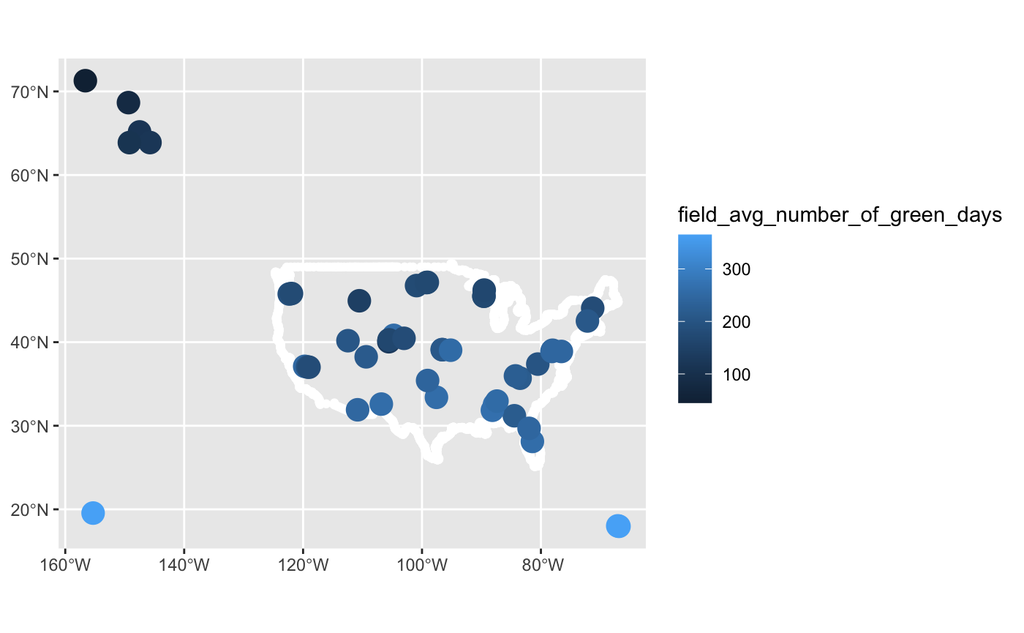

```r
ggplot() +
  geom_sf(data = usa, col="white") +
  geom_sf(data=terrestrial_sites,aes( color=field_avg_number_of_green_days), size=5) +
  coord_sf(xlim = c(bb[1], bb[3]), ylim = c(bb[2], bb[4]))
```

Filter your data with a bounding box to only include sites in the “west”

|  | field_domain_id | field_site_id | field_site_name | field_site_type | field_site_subtype | field_colocated_site | field_site_host | field_site_url | field_nonneon_research_allowed | field_access_details | field_neon_field_operations_office | field_geodetic_datum | field_utm_northing | field_utm_easting | field_utm_zone | field_site_county | field_site_state | field_site_country | field_mean_elevation_m | field_minimum_elevation_m | field_maximum_elevation_m | field_mean_annual_temperature_C | field_mean_annual_precipitation_mm | field_dominant_wind_direction | field_mean_canopy_height_m | field_dominant_nlcd_classes | field_domint_plant_species | field_usgs_huc | field_watershed_name | … |
| --- | --- | --- | --- | --- | --- | --- | --- | --- | --- | --- | --- | --- | --- | --- | --- | --- | --- | --- | --- | --- | --- | --- | --- | --- | --- | --- | --- | --- | --- | --- |
| 1 | D16 | ABBY | Abby Road NEON | Gradient Terrestrial |  |  | Washington Department of Natural Resources | https://www.dnr.wa.gov/ | Limited | Reseachers should coordinate with the site manager and submit a site research permit. | Domain 16 Support Facility | WGS84 | 5067870 | 552075.5 | 10N | Clark | WA | USA | 365 | NA | 708 | 10.0 | 2451 |  | 34m (in surrounding non-logged area) | Evergreen Forest\|Grassland/Herbaceous\|Shrub/Scrub | Gaultheria shallon (salal)\|Pseudotsuga menziesii (douglas fir)\|Pteridium aquilinum (bracken fern) |  |  | … |
| 7 | D10 | CPER | Central Plains Experimental Range NEON | Core Terrestrial |  |  | USDA-Agricultural Research Service | https://www.ars.usda.gov/plains-area/fort-collins-co/center-for-agricultural-resources-research/rangeland-resources-systems-research/docs/rrsr/central-plains-experimental-research-location/ | Yes | Reseachers should coordinate with the site manager. | Domain 10/13 Support Facility | WGS84 | 4518311 | 521454.8 | 13N | Weld | CO | USA | 1654 | 1601 | 1686 | 8.6 | 344 | NW | 0.4 | Grassland/Herbaceous | Bouteloua gracilis (Blue grama)\|Hesperostipa comata (Needle-and-thread grass)\|Thelesperma filifolium (Stiff greenthread) |  |  | … |
| 17 | D14 | JORN | Jornada Experimental Range NEON | Gradient Terrestrial |  |  | USDA-Agricultural Research Service | https://jornada.nmsu.edu/ | Yes | JORN encourages research activities that do not conflict with on-going activities. Please apply directly with site host and USDA for a site research permit. All requests are reviewed for impacts to cu… | Domain 14 Support Facility | WGS84 | 3607409 | 327074.6 | 13N | Dona Ana | NM | USA | 1324 | 1316 | 1333 | 15.7 | 271 | SW | 0.4 | Shrub/Scrub | Prosopis glandulosa (honey mesquite)\|Yucca elata (soaptree yucca)\|Bouteloua eriopoda (black grama grass) |  |  | … |
| 23 | D13 | MOAB | Moab NEON | Gradient Terrestrial |  |  | Bureau of Land Management | https://www.blm.gov/office/moab-field-office | Yes | Reseachers should coordinate with the site manager. | Domain 10/13 Support Facility | WGS84 | 4234597 | 641031.5 | 12N | San Juan | UT | USA | 1799 | 1722 | 2039 | 10.1 | 319 | SSW | 0.2 | Evergreen Forest\|Shrub/Scrub | Atriplex canescens (fourwing saltbush)\|Ephedra viridis (Mormon tea)\|Bouteloua gracilis (blue grama) . |  |  | … |
| 24 | D13 | NIWO | Niwot Ridge NEON | Core Terrestrial |  | COMO | US Forest Service, University of Colorado-Boulder |  | Yes | Reseachers should coordinate with the site manager and submit a site research permit. | Domain 10/13 Support Facility | WGS84 | 4433941 | 450328.3 | 13N | Boulder | CO | USA | 3490 | 2975 | 3583 | 0.3 | 1005 | WNW | 0.2 | Evergreen Forest\|Grassland/Herbaceous | Abies lasiocarpa (subapline fir)\|Picea engelmannii (Engelmann spruce)\|Vaccinium sp. (blueberry sp.) |  |  | … |
| 25 | D09 | NOGP | Northern Great Plains Research Laboratory NEON | Gradient Terrestrial |  |  | USDA Agricultural Research Service | https://www.ars.usda.gov/plains-area/mandan-nd/ngprl/ | Yes | This site host welcomes and encourages additional research activities related to the USDA Agricultural Research Service mission. | Domain 09 Support Facility | WGS84 | 5181356 | 353761.6 | 14N | Morton | ND | USA | 589 | 517 | 592 | 5.9 | 457 | NNE | 0.4 | Grassland/Herbaceous | Elaeagnus angustifolia (Russian olive)\|Poa pratensis (Kentucky bluegrass)\|Symphoricarpos occidentalis (Western snowberry) |  |  | … |
| 27 | D15 | ONAQ | Onaqui NEON | Core Terrestrial |  |  | Bureau of Land Management | https://www.blm.gov/office/salt-lake-field-office | Limited | Reseachers should coordinate with the site manager and submit a site research permit. | Domain 15 Support Facility | WGS84 | 4448480 | 376339.7 | 12N | Tooele | UT | USA | 1662 | 1599 | 2061 | 9.0 | 288 | SW | 1.2 | Evergreen Forest\|Shrub/Scrub | Artemisia tridentata (big sagebrush)\|Ceratocephala testiculata (curveseed butterwort)\|Bromus tectorum (cheatgrass) |  |  | … |
| 31 | D10 | RMNP | Rocky Mountains NEON | Gradient Terrestrial |  |  | Roosevelt National Forest | https://www.fs.usda.gov/arp | Yes | Researchers should coordinate directly with the US Forest Service for permitting and approval. | Domain 10/13 Support Facility | WGS84 | 4458524 | 453588.4 | 13N | Larimer | CO | USA | 2742 | 2454 | 3042 | 2.9 | 731 |  | 19 | Evergreen Forest | Pinus contorta (Lodgepole pine)\|Abies lasiocarpa (Subalpine fir)\|Pseudotsuga menziesii (Douglas-fir) |  |  | … |
| 34 | D17 | SJER | San Joaquin Experimental Range NEON | Core Terrestrial |  |  | US Forest Service | https://www.fs.fed.us/psw/ef/san_joaquin/ | Yes | Researchers should coordinate directly with the US Forest Service for permitting and approval. | Domain 17 Support Facility | WGS84 | 4110434 | 257214.0 | 11N | Madera | CA | USA | 400 | 252 | 502 | 16.4 | 540 | NW | 21 | Evergreen Forest\|Grassland/Herbaceous\|Shrub/Scrub | Quercus douglasii (blue oak)\|Erodium botrys (broadleaf filaree)\|Bromus diandrus (great brome) |  |  | … |
| 35 | D17 | SOAP | Soaproot Saddle NEON | Gradient Terrestrial |  |  | US Forest Service | https://www.fs.usda.gov/sierra/ | Yes | Researchers should coordinate directly with the US Forest Service for permitting and approval. | Domain 17 Support Facility | WGS84 | 4100967 | 298792.7 | 11N | Fresno | CA | USA | 1210 | 1044 | 1373 | 13.4 | 900 | NW | 32 | Evergreen Forest\|Shrub/Scrub | Arctostaphylos viscida ssp. Mariposa (mariposa manzanita)\|Chamaebatia foliolosa (mountain misery)\|Quercus chrysolepis (canyon live oak) |  |  | … |

[output cut: 5 more lines]

Plot your western points to confirm that you have properly filtered them.

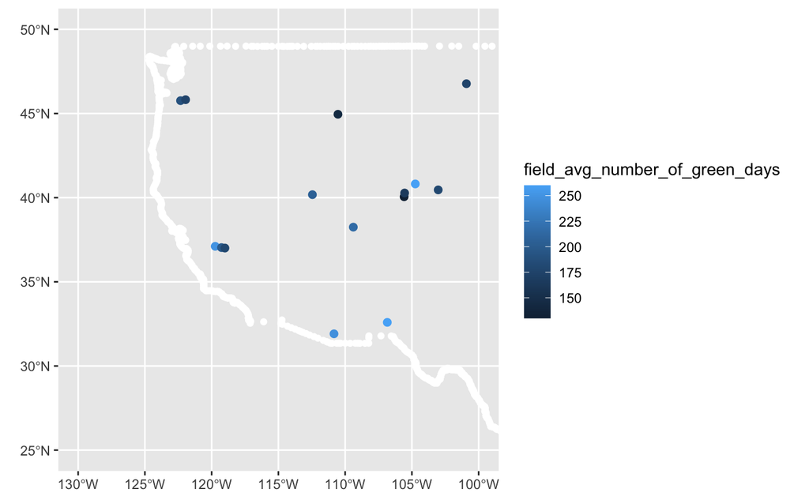

```r
ggplot() +
  geom_sf(data = usa, col="white") +
  geom_sf(data=west_us_terrestrial_neon_sites,aes( color=field_avg_number_of_green_days), size=2) +
  coord_sf(xlim = c(box[1], box[3]), ylim = c(box[2], box[4]))
```

Filter the western NEON sites to only include sites with Evergreen trees present.

```r
west_us_terrestrial_Evergreen_neon_sites <- metatdata %>%
  filter(field_site_type == "Core Terrestrial" | field_site_type == "Gradient Terrestrial" ) %>%
  filter(field_dominant_nlcd_classes !=  "Grassland/Herbaceous" & field_dominant_nlcd_classes !=  "Shrub/Scrub" & field_dominant_nlcd_classes != "Cultivated Crops") %>%
  st_crop(box)
as.data.frame(west_us_terrestrial_Evergreen_neon_sites)
```

|  | field_domain_id | field_site_id | field_site_name | field_site_type | field_site_subtype | field_colocated_site | field_site_host | field_site_url | field_nonneon_research_allowed | field_access_details | field_neon_field_operations_office | field_geodetic_datum | field_utm_northing | field_utm_easting | field_utm_zone | field_site_county | field_site_state | field_site_country | field_mean_elevation_m | field_minimum_elevation_m | field_maximum_elevation_m | field_mean_annual_temperature_C | field_mean_annual_precipitation_mm | field_dominant_wind_direction | field_mean_canopy_height_m | field_dominant_nlcd_classes | field_domint_plant_species | field_usgs_huc | field_watershed_name | … |
| --- | --- | --- | --- | --- | --- | --- | --- | --- | --- | --- | --- | --- | --- | --- | --- | --- | --- | --- | --- | --- | --- | --- | --- | --- | --- | --- | --- | --- | --- | --- |
| 1 | D16 | ABBY | Abby Road NEON | Gradient Terrestrial |  |  | Washington Department of Natural Resources | https://www.dnr.wa.gov/ | Limited | Reseachers should coordinate with the site manager and submit a site research permit. | Domain 16 Support Facility | WGS84 | 5067870 | 552075.5 | 10N | Clark | WA | USA | 365 | NA | 708 | 10.0 | 2451 |  | 34m (in surrounding non-logged area) | Evergreen Forest\|Grassland/Herbaceous\|Shrub/Scrub | Gaultheria shallon (salal)\|Pseudotsuga menziesii (douglas fir)\|Pteridium aquilinum (bracken fern) |  |  | … |
| 19 | D13 | MOAB | Moab NEON | Gradient Terrestrial |  |  | Bureau of Land Management | https://www.blm.gov/office/moab-field-office | Yes | Reseachers should coordinate with the site manager. | Domain 10/13 Support Facility | WGS84 | 4234597 | 641031.5 | 12N | San Juan | UT | USA | 1799 | 1722 | 2039 | 10.1 | 319 | SSW | 0.2 | Evergreen Forest\|Shrub/Scrub | Atriplex canescens (fourwing saltbush)\|Ephedra viridis (Mormon tea)\|Bouteloua gracilis (blue grama) . |  |  | … |
| 20 | D13 | NIWO | Niwot Ridge NEON | Core Terrestrial |  | COMO | US Forest Service, University of Colorado-Boulder |  | Yes | Reseachers should coordinate with the site manager and submit a site research permit. | Domain 10/13 Support Facility | WGS84 | 4433941 | 450328.3 | 13N | Boulder | CO | USA | 3490 | 2975 | 3583 | 0.3 | 1005 | WNW | 0.2 | Evergreen Forest\|Grassland/Herbaceous | Abies lasiocarpa (subapline fir)\|Picea engelmannii (Engelmann spruce)\|Vaccinium sp. (blueberry sp.) |  |  | … |
| 22 | D15 | ONAQ | Onaqui NEON | Core Terrestrial |  |  | Bureau of Land Management | https://www.blm.gov/office/salt-lake-field-office | Limited | Reseachers should coordinate with the site manager and submit a site research permit. | Domain 15 Support Facility | WGS84 | 4448480 | 376339.7 | 12N | Tooele | UT | USA | 1662 | 1599 | 2061 | 9.0 | 288 | SW | 1.2 | Evergreen Forest\|Shrub/Scrub | Artemisia tridentata (big sagebrush)\|Ceratocephala testiculata (curveseed butterwort)\|Bromus tectorum (cheatgrass) |  |  | … |
| 26 | D10 | RMNP | Rocky Mountains NEON | Gradient Terrestrial |  |  | Roosevelt National Forest | https://www.fs.usda.gov/arp | Yes | Researchers should coordinate directly with the US Forest Service for permitting and approval. | Domain 10/13 Support Facility | WGS84 | 4458524 | 453588.4 | 13N | Larimer | CO | USA | 2742 | 2454 | 3042 | 2.9 | 731 |  | 19 | Evergreen Forest | Pinus contorta (Lodgepole pine)\|Abies lasiocarpa (Subalpine fir)\|Pseudotsuga menziesii (Douglas-fir) |  |  | … |
| 29 | D17 | SJER | San Joaquin Experimental Range NEON | Core Terrestrial |  |  | US Forest Service | https://www.fs.fed.us/psw/ef/san_joaquin/ | Yes | Researchers should coordinate directly with the US Forest Service for permitting and approval. | Domain 17 Support Facility | WGS84 | 4110434 | 257214.0 | 11N | Madera | CA | USA | 400 | 252 | 502 | 16.4 | 540 | NW | 21 | Evergreen Forest\|Grassland/Herbaceous\|Shrub/Scrub | Quercus douglasii (blue oak)\|Erodium botrys (broadleaf filaree)\|Bromus diandrus (great brome) |  |  | … |
| 30 | D17 | SOAP | Soaproot Saddle NEON | Gradient Terrestrial |  |  | US Forest Service | https://www.fs.usda.gov/sierra/ | Yes | Researchers should coordinate directly with the US Forest Service for permitting and approval. | Domain 17 Support Facility | WGS84 | 4100967 | 298792.7 | 11N | Fresno | CA | USA | 1210 | 1044 | 1373 | 13.4 | 900 | NW | 32 | Evergreen Forest\|Shrub/Scrub | Arctostaphylos viscida ssp. Mariposa (mariposa manzanita)\|Chamaebatia foliolosa (mountain misery)\|Quercus chrysolepis (canyon live oak) |  |  | … |
| 33 | D17 | TEAK | Lower Teakettle NEON | Gradient Terrestrial |  |  | US Forest Service | https://www.fs.usda.gov/sierra/ | Yes | Researchers should coordinate directly with the US Forest Service for permitting and approval. | Domain 17 Support Facility | WGS84 | 4097400 | 321515.7 | 11N | Fresno | CA | USA | 2149 | 2086 | 2734 | 8.0 | 1223 | NW | 35 | Evergreen Forest\|Shrub/Scrub | Abies magnifica (red fir)\|Abies concolor (white fir)\|Pinus contorta (lodgepole pine) |  |  | … |
| 39 | D16 | WREF | Wind River Experimental Forest NEON | Core Terrestrial |  |  | Pacific Northwest Research Station, US Forest Service | https://www.fs.usda.gov/pnw/ | Yes | Reseachers should coordinate with the site manager and submit a site research permit. Various on-going research projects to be aware of at site. | Domain 16 Support Facility | WGS84 | 5074637 | 581417.8 | 10N | Skamania | WA | USA | 351 | 300 | 1008 | 9.2 | 2225 | NW | 50 | Evergreen Forest | Gaultheria shallon (salal)\|Psuedotsuga menziesii (douglas fir)\|Tsuga heterophylla (western hemlock) |  |  | … |
| 40 | D12 | YELL | Yellowstone National Park NEON | Core Terrestrial |  | BLDE\|YELL | National Park Service | https://irma.nps.gov/rprs/ | Limited | The National Park Service is open to additional research activities taking place in this area. Apply via IRMA Permitting portal. NEON research area is limited to additional research due to sensitivity… | Domain 12 Support Facility | WGS84 | 4977886 | 536352.2 | 12N | Park | WY | USA | 2133 | 1847 | 2244 | 3.4 | 493 | SSE | 14 | Evergreen Forest\|Grassland/Herbaceous\|Shrub/Scrub | Artemisia tridentata (big sagebrush)\|Pseudotsuga menziesii (douglas fir)\|Pinus contorta (lodgepole pine) |  |  | … |

Plot your Evergreen filter to confirm that your filter worked properly.

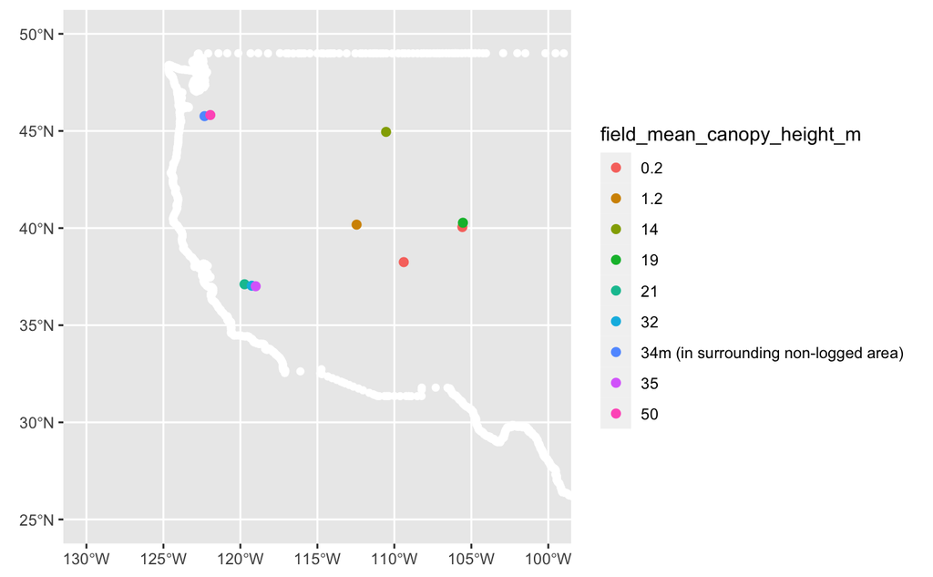

```r
ggplot() +
  geom_sf(data = usa, col="white") +
  geom_sf(data=west_us_terrestrial_Evergreen_neon_sites,aes( color=field_mean_canopy_height_m), size=2) +
  coord_sf(xlim = c(box[1], box[3]), ylim = c(box[2], box[4]))
```

## Learn how to use an API

Select one of the sitecodes from your filtered metadataset above and enter it below. Follow the tutorial offered by NEON to explore the data structure and organizational scheme for neon api data.

https://www.neonscience.org/resources/learning-hub/tutorials/neon-api-01-introduction-requests

```python
SERVER = 'http://data.neonscience.org/api/v0/'
SITECODE = 'NIWO'

site_request = requests.get(SERVER+'sites/'+SITECODE)

#Convert to Python JSON object
site_json = site_request.json()
site_json.keys()

site_json['data'].keys()

site_json
```

```python
site_json['data'].keys()
```

```
dict_keys(['siteCode', 'siteName', 'siteDescription', 'siteType', 'siteLatitude', 'siteLongitude', 'stateCode', 'stateName', 'domainCode', 'domainName', 'deimsId', 'releases', 'dataProducts'])
```

```python
for product in site_json['data']['dataProducts']:
    print(product['dataProductCode'],product['dataProductTitle'])
```

```python
PRODUCTCODE = 'DP2.30011.001'
```

```python
#Get available months of Breeding Landbird Count data products for TEAK site
#Loop through the 'dataProducts' list items (each one a dict) at the site
for product in site_json['data']['dataProducts']:
    if(product['dataProductCode'] == PRODUCTCODE): #If a list item's 'dataProductCode' dict element equals the product code string,
        print('Available Months: ',product['availableMonths']) #print the available months and URLs
        print('URLs for each Month: ', product['availableDataUrls'])
```

```python
#Make Request
data_request = requests.get(SERVER+'data/'+PRODUCTCODE+'/'+SITECODE+'/'+'2020-08')
data_json = data_request.json()

print(data_json)
```

```r
py$data_json
```